# Warmup 01: Markdown Syntax

Jiaxin Chen

1/28/2019

### Star Wars

#### Kazuda Xiono

> “*In my mind, that’s what I was—Kazuda Xiono, the best starfighter pilot in the galaxy.*”

> -*Kazuda Xiono, to Poe Dameron and Neeku Vozo*

[figure not shown]

| Description | Value |
| --- | --- |
| Homeworld | Hosnian Prime |
| Born | 14 ABY, Hosnian Prime |
| Species | Human |
| Gender | Male |
| Hair color | Black |
| Eye color | Brown |
| Skin color | Light |

### Cooking Recipe

#### Root Vegetable Gratin

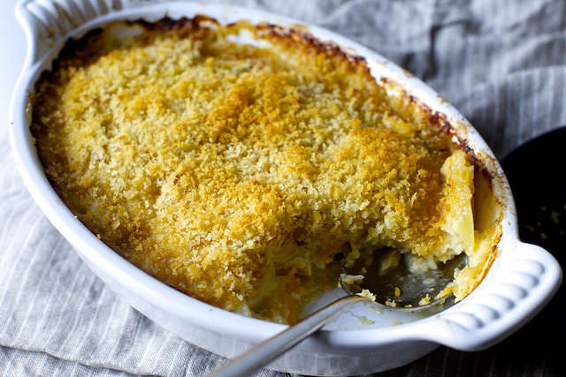

##### Ingredients

- Olive oil
- 1 large onion, sliced (1 1/2 cups)
- 2 cups (1/4-inch-sliced) fennel, top and core, if thick, removed
- 3 cloves garlic, minced (1 tablespoon)
- 1 pound sweet potatoes, peeled and sliced 1/4-inch thick
- 1 pound celery root, peeled and sliced 1/4-inch thick
- 1 pound yukon gold, peeled and sliced 1/4-inch thick
- 1 cup heavy cream (see Note up top)
- 2 cups chicken or vegetable stock or brother
- 2 cups grated gruyere cheese (6 ounces with rind)
- 2 teaspoons minced fresh thyme leaves
- Kosher salt and freshly ground black pepper
- 2 1/2 cups coarse fresh breadcrumbs or panko (what I used)
- 2 to 3 tablespoons melted butter

##### “Special Kitchen Tools”

- Two pans
- one 3-quart baking dish (freezing the larger one until you need it)
- one 1-quart baking dish
- oven

##### Steps of making Root Vegetable Gratin

1. Keep 2 cups chicken broth and 1 cup cream in the fridge.
2. Heat your oven to 350°F.
3. Butter a 13×9-inch deep baking dish.
4. Heat 2 tablespoons olive oil in a large deep (ideally 12-inch) saute pan over medium heat and add the onions and fennel.
5. Cooking, tossing occasionally, until lightly browned and tender, about 10 minutes.
6. Add the garlic and cook for one minute more.
7. combine the onion mixture with remaining vegetables, cream, stock, cheese, thyme, 1 tablespoon kosher salt and 1 1/2 teaspoons black pepper.
8. Pour mixture into prepared dish and spread until even.
9. Mix breadcrumbs and butter until evenly coated and distribute evenly over top of dish.
10. Bake 1 1/2 hours uncovered, or until vegetables are very tender when tested with a small knife and the top is browned and bubbly.

##### Variations of the recipe

Garten’s original recipe calls for 1/2 cup chicken broth and 2 1/2 cups heavy cream. Because do not like gratins to be this rich and find much less cream goes a long way to impart richness, but not the kind that muffles flavors, so used 2 cups broth and 1 cup cream. You can add 1 cup of mascarpone and/or creme fraiche in a gratin.

### Euclidean Distance

#### Definition

The **Euclidean distance** between points **p** and **q** is the length of the line segment connecting them ($\bar{pq}$)

In [Cartesian coordinates](https://en.wikipedia.org/wiki/Cartesian_coordinate_system), if **p** = (p1, p2,…, pn) and **q** = (q1, q2,…, qn) are two points in Euclidean n-space, then the distance (d) from **p** to **q**, or from **q** to **p** is given by the [Pythagorean formula](https://en.wikipedia.org/wiki/Pythagorean_theorem):

$$\begin{equation} \label{eql1}
\begin{split}
d(\boldsymbol{p}, \boldsymbol{q}) = d(\boldsymbol{q}, \boldsymbol{p}) & = \sqrt{(q_1-p_1)^2+(q_2-p_2)^2+\dots+(q_n-p_n)^2} \\
& = \sqrt{ \sum_{i=1}^{n} (q_i - p_i)^2 }
\end{split}
\end{equation}$$

The position of a point in a Euclidean n-space is a [Euclidean vector](https://en.wikipedia.org/wiki/Euclidean_vector). So, **p** and **q** may be represented as Euclidean vectors, starting from the origin of the space (initial point) with their tips (terminal points) ending at the two points. The Euclidean norm, or **Euclidean length**, or **magnitude** of a vector measures the length of the vector:

|**p**| = $\sqrt{p_1^2 + p_2^2 + \dots + p_n^2}$ = $\sqrt{\boldsymbol{p}\cdot \boldsymbol{p}}$

where the last expression involves the [dot product](https://en.wikipedia.org/wiki/Dot_product).